# Lab 7: Predator-prey models

Your name

2024-02-23

### **Learning Objectives**

- Learn and understand key terminology regarding predator-prey/parasitoid-host models
- Develop a discrete-time population dynamics model

### **Grading Rubric**

Most of your grade will be for effort - i.e., that you did your best to follow instructions and to answer questions. Each lab is worth 30 pts, so divide this number by the total number of questions to estimate the approximate number of points per question. Points may be deducted for errors in code, not following instructions, or answering questions incorrectly.

### **Instructions**

There are a set of questions associated with each exercise below that you must complete either during class or on your own time. Record answers to the questions **within** the Markdown (`.Rmd`) file and record your name on line 2. Once you’re done with the lab, knit the R markdown file as a Word document (`.docx`) within RStudio by clicking the `Knit` button found in the toolbar (look for a ball of yarn with a needle sticking out of it) and selecting `Knit to Word`. Ignore any warning messages that pop up in the Console during knitting. Submit the `.Rmd` **and** the `.docx` files on Canvas.

### **Introduction**

In the 1930s, Nicholson and Bailey proposed a simple discrete-time model to simulate the population dynamics of insect hosts and their parasitoids. Parasitoids are insects that lay their eggs on a host, eventually killing it as larvae develop. Parasitoidism is a type parasitism, but the fatal prognosis for the host makes the strategy close to predation. Most parasitoids are wasps, but some flies and a small number of beetles, moths, lacewings, and even one caddisfly species have evolved to be parasitoids. It is estimated that ca. 10% of insect species (mostly *Hymenoptera* wasps and *Diptera* flies) are parasitoids! The pictures below shows a braconid wasp attacking a spongy moth (*Lymanatria dispar*) caterpillar. Interestingly, braconid wasps inject caterpillars with a virus known as a bracoviruses, which suppresses the caterpillar’s immune system to favor growth of their progeny. Parasitoids are frequently used as natural enemies in the biological control of insect pests, where the goal is often to establish a long-term, persistent pest-parasitoid interaction to suppress pest densities to an economically tolerable threshold. Much of the theory on host–parasitoid interactions, therefore, has focused on determining what mechanisms can lead to a stable equilibrium with a low host density.

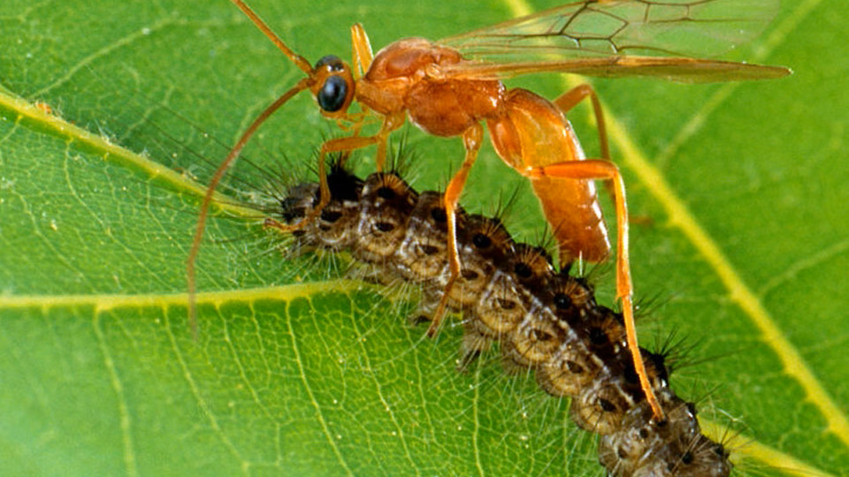

Credit: USDA/Wikimedia

The figure below shows a generalized diagram of a parasitoid wasp life cycle. In the figure, the adult female injects virus particles along with the eggs during parasitization. Different species will differ in regards to the number of eggs laid and whether they lay eggs on the host or inject a single egg into the host.

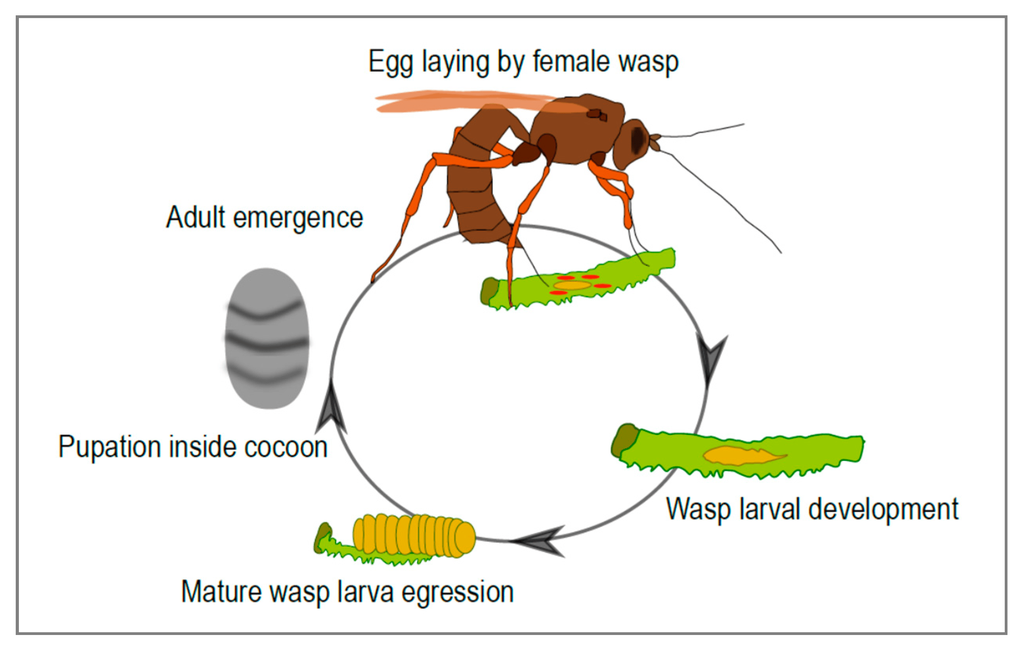

Credit: Volkoff and Cusson (2020) https://doi.org/10.3390/v12101170

### **The Nicholson-Bailey Model**

The Nicholson-Bailey model is considered a classical model of population biology (Nicholson & Bailey 1935, https://doi.org/10.1111/j.1096-3642.1935.tb01680.x). A central characteristic of the Nicholson-Bailey model is that both populations undergo oscillations with increasing amplitude until first the host and then the parasitoid population dies out. This lab introduces the simple version of the model and then adds parameters to potentially lead to a stable host-parasitoid equilibrium.

The Nicholson-Bailey model makes several initial assumptions:

1. Hosts are uniformly distributed in the environment
2. Host and parasitoid have a single generation per year, then die
3. Host-parasitoid encounters occur at random
4. Population growth rates are known and constant (no density dependence)
5. The interaction can be captured as a discrete-time model tracking: Host ($H_t$) and Parasitoid ($P_t$) densities in year $t$
6. No stage structure - no tracking of non-reproductive immatures
7. Parasitoids can attack/consume an unlimited number of hosts and have unlimited ability to lay eggs
8. Searching efficiency of parasitoid $a$ is linear ([type 1 functional response](https://en.wikipedia.org/wiki/Functional_response))

#### **Equations**

The Nicholson-Bailey model calculates host ($H_t$) and parasitoid ($P_t$) densities for a given year using equations given by

$$H_{t+1} = RH_te^{-aP_t}$$
$$P_{t+1} = cH_t(1 - e^{-aP_t})$$
where $R$ is the host net reproductive rate (number of new hosts produced by one unparasitized host - equivalently $R = e^r$ where $r$ is the intrinsic growth rate), and $c$ (conversion efficiency) is the number of new parasitoids produced by a parasitized host. The host is attacked at a rate $aP_t$, where $a$ is the parasitoid searching efficiency. The probability that a host escapes parasitism can be approximated by $e^{-aP_t}$; therefore, the probability to become parasitized is given by $(1 - e^{-aP_t})$.

These equations are coded in R as follows.

```r
# Equations
H <- R * log(R)/(a*c*(R-1)) # Starting host density
P <- log(R)/a # Starting parasitoid density
```

A host-parasitoid equilibrium exists ($H > 0$, $P > 0$) whenever $R > 1$, i.e., whenever the host population would increase in the absence of the parasitoid. The equilibrium host density decreases as the number of parasitoid eggs per host increases, and both host and parasitoid densities decrease with increasing parasitoid attack rate. However, this equilibrium is unstable. To illustrate this point, we will run a simulation using a function that describes the simple Nicholson-Bailey model.

#### **(1) Model Function**

Below we create our own function that contains code to model host ($H_t$) and parasitoid ($P_t$) densities over time using the simple Nicholson-Bailey model. Four arguments are passed to the function:  
1) `time` $t$ (number of years)  
2) initial values for $R$ (host net reproductive rate)  
3) $c$ (number of new parasitoids), and 4) $a$ (parasitoid searching efficiency)

```r
# Simple Nicholson-Bailey model
# Agurments are # of time steps, pop growth rate, search efficiency, and search area.
NB_model <- function(time, R, c, a) {

  # Equations
  H <- R * log(R)/(a*c*(R-1)) # Starting host density
  P <- log(R)/a # Starting parasitoid density

  # Data frame to hold all model outputs, where the first row is for time 0
  nb_out_all <- data.frame("Time" = 0, "H" = H+1, "P" = P)

  # Loop through all years in "time" (number of years) and calculate H and P,
  # which are then added to the "nb_out_all" data frame
  for (i in 1:(time-1)) {
    H <- R * nb_out_all$H[i] * exp(-a * nb_out_all$P[i])
    P <- c * nb_out_all$H[i] * (1-exp(-a * nb_out_all$P[i]))
    nb_out_all <- add_row(nb_out_all, Time = i, H = H, P = P)
  }

  # Change all values below 1 to 0
  nb_out_all <- nb_out_all %>%
    mutate(H = ifelse(H < 1, 0, H), P = ifelse(P < 1, 0, P))

  # Return the results from the function
  return(nb_out_all)
}
```

#### **Example**

As an example, we’ll run the model using the initial conditions below.

```r
# Initial conditions
c <- 2 # No. of parasitoids that hatch from infected host
a <- 0.5 # Searching efficiency of female parasitoid
R <- 2 # Reproductive rate (number of surviving host offspring)
time <- 30 # No. of generations (years)

# Run the model
nb_model_df1 <- NB_model(time = time, R = R, c = c, a = a)
```

The `nb_model_df1` data frame contains host and parasitoid outputs for each year.

```r
# View the first several rows of the output
head(nb_model_df1)
```

```
##   Time        H        P
## 1    0 2.386294 1.386294
## 2    1 2.386294 2.386294
## 3    2 1.447361 3.325228
## 4    3 0.000000 2.345759
## 5    4 0.000000 0.000000
## 6    5 0.000000 0.000000
```

Two plotting functions that use the `ggplot2` package are used to view the results. Populations densities can be plotted against time (state space) as well as against one another (phase space). The first function plots densities against time (`Plot_DensVTime`). Prior to plotting, the model outputs are transformed using the [`pivot_longer()`](https://tidyr.tidyverse.org/reference/pivot_longer.html) function of the [`tidyr`](https://tidyr.tidyverse.org/) package to create a single column named `Density` that combines the `H` and `P` columns.

#### **(2) Function to Plot Densities vs. Time**

```r
# Function to plot densities against time
Plot_DensVTime <- function(model_out, plot_title) {

  # Reformat model outputs to create a single "Density" column
  model_out_long <- pivot_longer(model_out, names_to = "Species",
                         cols = c(H, P),
                         values_to = "Density")

  # Get max density value so can create same max value for axis
  max_dens <- max(model_out_long$Density)

  # Vector of parameter values for varying parameter
  plot <- ggplot(model_out_long, aes(x = Time, y = Density, color = Species, group = Species)) +
    # Data points for each generation
    geom_point(size = 0.5) +
    # Connect data points with a line
    geom_line() +
    # Use different colors for each species
    scale_color_manual(values = c("blue", "red"), labels = c("Host", "Parasitoid")) +
    # Plot theme
    theme_bw() +
    theme(text = element_text(size = 11)) +
    # Axis labels and title
    xlab("Time (years)") +
    ggtitle(paste("Initital conditions:", plot_title)) +
    # Force x axis to start at 0
    scale_x_continuous(expand = c(0, 0), breaks = seq(0, max(model_out_long$Time), 5))

  return(plot)
}
```

#### **(3) Function to Plot Host vs. Parasitoid Densities**

```r
# Function to plot densities against each other
Plot_DensVDens <- function(model_out, plot_title) {

  # Vector of parameter values for varying parameter
 plot <- ggplot(model_out, aes(x = H, y = P, color = Time)) +
   # Data points for each generation
   geom_point() +
   # Connect points according to generation and add color to points and path
   geom_path() +
   scale_color_gradient2(low="blue", mid = "gold2", high="red3",
                         midpoint = median(model_out$Time)) +
   # Plot theme
   theme_bw() +
   theme(text = element_text(size = 11)) +
   # Axis labels and title
   xlab("Host density") +
   ylab("Parasitoid density") +
   ggtitle(paste("Initital conditions:", plot_title))

 return(plot)
}
```

A plot depicting the dynamics of host and parasitoid densities over time demonstrates how the simple Nicholson-Bailey model leads to mutual extinction of host and parasitoid. Realistically, there shouldn’t even be a second peak in the plot because densities drop to 0 at year 3 (host) or year 4 (parasitoid).

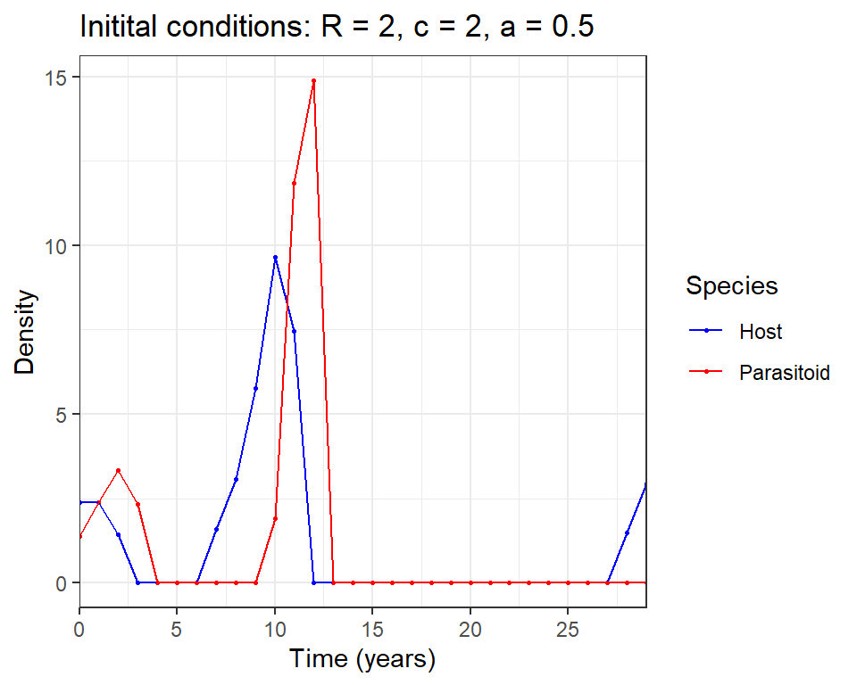

```r
# Time vs. density plot with informative plot title
plot_title1 <- paste0("R = ", R, ", c = ", c, ", a = ", a)
plot_densVtime1 <- Plot_DensVTime(nb_model_df1, plot_title1)
plot_densVtime1
```

Plotting host vs. parasitoid densities reveals how the trajectory spirals outwards until the population crashes.

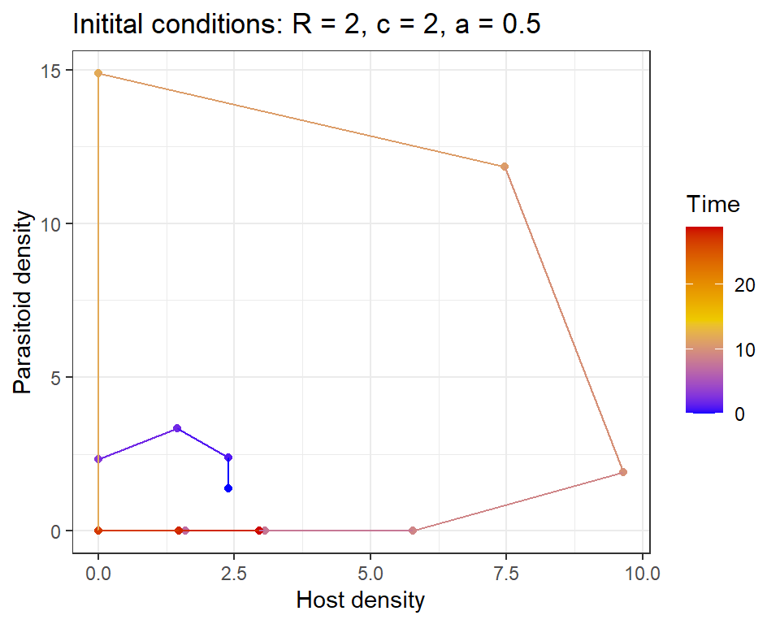

```r
# Phase diagram
plot_densVdens1 <- Plot_DensVDens(nb_model_df1, plot_title1)
plot_densVdens1
```

### **Exercise 1: The Simple Nicholson-Bailey model**

#### **Simple Model**

**(1)** In the code chunk below, run the model using starting conditions that reflect a situation in which a parasitoid oviposits one egg per host, has a searching efficiency of 75%, and a reproductive rate of `2`. Run the model for `30` generations (years). Create plots of the model output (i.e., using the `Plot_DensVTime` and `Plot_DensVDens` functions). Make sure to create a new plot title.

```r
# Initial conditions
# c <- ? No. of parasitoids that hatch from infected host
# a <- ? # Searching efficiency of female parasitoid
# R <- ? # Reproductive rate (number of surviving host offspring)
#time <- ? # No. of generations (years)

# Run the model
# Can name output `nb_model_df2`

# Plot the results
# Can name plots `plot_densVtime2` and `plot_densVdens2`, and plot title `plot_title2`
```

**(2)** Use the same parameters as before except change the searching efficiency to 5%, and then answer the question below.

```r
# Initial conditions

# Run the model
# Can name output `nb_model_df3`

# Plot the results
# Can name the plots `plot_densVtime3` and `plot_densVdens3`, and plot title `plot_title3`
```

What was the main effect of changing the parasitoid searching efficiency, and why?

*Response:*

**(3)** Repeat this process for the other two parameters, reproductive rate (`R`) and number of hatched parasitoids (`c`), but choose your own values this time. See the comments below for naming conventions (avoids confusion later). Then answer the question below.

```r
# Initial conditions

# Run the model for 2 values of `R`
# Name output `nb_model_df4`

# Plot the results
# Name the plots `plot_densVtime4` and `plot_densVdens4`, and plot title `plot_title4`

# Run the model for 2 values of `c`
# Name the plots `plot_densVtime5` and `plot_densVdens5`, and plot title `plot_title5`
```

What was the main effect of changing each of the parameters, and why?

*Response:*

**(4)** Why does the simple Nicholson-Bailey model show unstable oscillations and eventually lead to mutual population extinction?

*Response:*

### **Exercise 2: Adding Host Density Dependence**

Remarkably stable parasitoid-host interactions can be found in nature, which suggests that a simple Nicholson-Bailey model is lacking or misrepresenting some important feature or mechanism present in real systems. Adding density dependence in the rate of increase of the host is one step towards stabilizing the host-parasitoid equilibrium. You can include host self-regulation by modifying the host growth rate, $R$ (equivalently, $e^r$). There is more than one way to do this, but the below equations provide a solution of how to modify your equation.

If the $e^r$ notation is used, then the Nicholson-Bailey model can be written as

$$H_{t+1} = e^rH_te^{-aP_t}$$
$$P_{t+1} = cH_t(1 - e^{-aP_t})$$
which can be simplified to
$$H_{t+1} =
H_te^{r-aP_t}$$
$$P_{t+1} = cH_t(1 -
e^{-aP_t})$$

The addition of density-dependence can be achieved by replacing $R$ with $r - rH/K$, where $K$ is the host carrying capacity
$$H_{t+1} =
H_te^{r-rH/K-aP_t}$$
$$P_{t+1} =
cH_t(1 - e^{-aP_t})$$

In the empty code chunk below, create a Nicholson-Bailey model that includes host density dependence and name it `NB_model_K`. It will probably be easiest to just copy and paste the `NB_model` function from above and change the equations for calculating $H$ and $P$. Hint: your new equation for $H$ should include a carrying capacity, $K$, parameter, and you will now have `K` as a fifth argument for the function.

```r
# Simple Nicholson-Bailey model with host density dependence (K)
```

**(5)** In the empty code chunk below, run your model and use the two plotting functions to create plots of model outputs. Use the below initial values for this question and the next.

```r
# Initial conditions
c <- 3 # No. of parasitoids that hatch from infected host
a <- 0.001 # Searching efficiency of female parasitoid
R <- 1.1 # Reproductive rate (number of surviving host offspring)
K <- 750 #
time <- 100 # No. of generations (years)

# Run the model
# Can name output `nb_model_df6`

# Plot the results
# Can name the plots `plot_densVtime6` and `plot_densVdens6`, and plot title `plot_title6`
```

Below, we are going to explore the effect of varying values for several model parameters. A function is used to avoid repeating code. The function, `ParamRunner()`, requires the name of the parameter that is changing (in character format) and the range of values to be tested. A `for` loop iterates through each value and runs the `nb_model_K` function. Two output plots are combined using the [`wrap_plots()`](https://www.rdocumentation.org/packages/patchwork/versions/1.1.2/topics/wrap_plots) function in the [`patchwork`](https://patchwork.data-imaginist.com/) and saved in a list. After the loop finishes, all plots are combined (total of 12 plots) and saved.

#### **Function to Model Multiple Parameter Values**

```r
# Function to run model for each param, and combine plots and save them
ParamRunner <- function(param, values) {

  # For each value of R, run the model and produce both plot types
  # List to store plots
  plot_list <- list()

  # Loop through all values of "R"
  for (i in 1:length(values)) {

    # Run the model
    val_i <- values[i]

    # Run model using correct arguments, and create plot title
    if (param == "R") {
      nb_model_df <- NB_model_K(time, val_i, c, a, K)
      plot_title <- paste0("R = ", val_i, ", c = ", c, ", a = ", a, ", K = ", K)
    } else if (param == "c") {
      nb_model_df <- NB_model_K(time, R, val_i, a, K)
      plot_title <- paste0("R = ", R, ", c = ", val_i, ", a = ", a, ", K = ", K)
    } else if (param == "a") {
      nb_model_df <- NB_model_K(time, R, c, val_i, K)
      plot_title <- paste0("R = ", R, ", c = ", c, ", a = ", val_i, ", K = ", K)
    } else if (param == "K") {
      nb_model_df <- NB_model_K(time, R, c, a, val_i)
      plot_title <- paste0("R = ", R, ", c = ", c, ", a = ", a, ", K = ", val_i)
    }

    # Make plots of output
    plot_densVtime <- Plot_DensVTime(nb_model_df, plot_title) # Density vs. Time
    plot_densVdens <- Plot_DensVDens(nb_model_df, plot_title) # Density vs. Density
    both_plots <- patchwork::wrap_plots(plot_densVtime, plot_densVdens, ncol = 2) # Combine

    # Store outputs in the list
    plot_list[[i]] <- both_plots
}

  # Combine plots for all values of R to make 1 big final plot
  allPlots <- patchwork::wrap_plots(plot_list, ncol = 1)

  # Save the final plot as a .PNG file
  outfile <- paste0("NB_vary_", param, "_plot.png")
  ggsave(allPlots, filename = here("Lab7_predator_prey_model", "plots", outfile),
        height = 15, width = 15, units = c('in'), device = "png", dpi = 150)
}
```

**(6)** Explore how densities of the host and parasitoid change over time when changing:  
(1) the host reproductive rate ($R$, number of surviving host offspring)  
(2) the number of parasitoids that emerge from an infected host ($c$)  
(3) the search area of female parasitoids ($a$)  
(4) the host carrying capacity ($K$)

For each test, use 6 different values for one parameter while keeping all other parameters at the initial values in the code chunk below. If no change is observed, try using a larger range of values for the variable parameter.

Below is an example of what your code might look like **after** you have created a functioning model (`nb_model_K`). In the example, we iterate through a sequence of $R$ values created using the `seq()` function, and then implement the `ParamRunner()` function to run the model and create a combo plot of results.

**(6a)** Varying $R$.

```r
# Initial conditions
c <- 3 # No. of parasitoids that hatch from infected host
a <- 0.001 # Searching efficiency of female parasitoid
K <- 750 # Host density dependence
time <- 100 # No. of generations (years)

# Reproductive rate (number of surviving host offspring)
#"seq" produces a sequence of numbers in specified increments
# Make sure the vector contains only 6 values
R_values <- seq(from = 1.3, to = 2.8, by = 0.3)

# Run custom function to run model and create and save plots
ParamRunner(param = "R", values = R_values)
```

**(6b)** Varying $c$.

```r
# Changing number of eggs per host, c
# Keep other param values the same as in 6a
# c_values <- ?

# For each value of c, run the model and produce both plot types
# Run custom function to run model and create and save plots
```

**(6c)** Varying $a$.

```r
# Changing search efficinecy parameter "a"
# Keep other param values the same as in 6a
# a_values <- ?

# Run custom function to run model and create and save plots
```

**(6d)** Varying $K$.

```r
# Changing K (host density dependence)
# Keep other param values the same as in 6a
# K_values <- ?

# Run custom function to run model and create and save plots
```

Examples of plots for each run are in the `example_plots` folder. Your plots will probably look different since you’re choosing your own parameter values.

**(7)** Summarize how variation in each of the 4 parameters ($R$, $c$, $a$, and $K$) affects how host and parasitoid densities change over time. Keep in mind that y-axis limits may differ across the plots produced for each parameter value.

*Response*:

**(8)** Does your modified Nicholson-Bailey model still show unstable oscillations and eventually lead to mutual population extinction? Did some parameter combinations result in greater stability? Explain.

*Response*:

**(9)** Which factor would you add next to stabilize the model and why?

*Response*:

**(10)** Discuss your overall results from the Nicholson-Bailey model simulations. In your response, describe some potential applications of the model, such as for biological control programs of insect pests. What qualities would you look for in the parasitoid?

*Response*: